# Indice Reclutamiento D. trunculus

Datos Monitoreo poblacional FEMP_AND_04

Mardones, M; Delgado, M

20 March, 2024

```r
rm(list = ls())
knitr::opts_chunk$set(echo = TRUE,
                      message = FALSE,
                      warning = FALSE,
                      fig.align = 'center',
                      dev = 'jpeg',
                      dpi = 300,
                      fig.align='center')
#XQuartz is a mess, put this in your onload to default to cairo instead
options(bitmapType = "cairo")
# (https://github.com/tidyverse/ggplot2/issues/2655)
# Lo mapas se hacen mas rapido
```

```r
library(tidyverse)
library(ggridges)
library(readxl)
library(here)
library(lubridate)
library(readr)
library(ggthemes)
library(hrbrthemes)
library(viridis)
library(kableExtra)
library(ggalt)
library(psych)
library(ggpubr)
```

# CONTEXTO

En este codigo, se establecen dos formas de estimar el indice de reclutamiento para coquina. El primero es la forma que se ha estado usando desde Delgado & Caparro (2015). El segundo es una nueva propuesta basada en la prorporcionalidad de individuos basados en los muestreos poblacionales

# INDICE DE RECLUTAMIENTO POBLACIONAL (D15)

## Bases de Densidades

Recordar que las bases de densidades previas al 2021 estan en la misma base que las longitudes. pero he encontrado un archivo que tiene una sintesis

```r
dens17_20 <- read_excel("Data/Anterior a 2020/densidad_reclutamiento_2017_2018_2019_2020.xlsx")
```

```r
dens2021pob <- read_excel(here("Data", "Posterior 2020",
                               "Data_sample_FEMP_04_2021.xlsx"),
                       sheet = "Data_POBL")
dens2022pob <- read_excel(here("Data", "Posterior 2020",
                               "Data_sample_FEMP_04_2022.xlsx"),
                       sheet = "Data_POBL")
dens2023pob <- read_excel(here("Data", "Posterior 2020",
                               "Data_sample_FEMP_04_2023.xlsx"),
                       sheet = "Data_POBL")
dens2024pob <- read_excel(here("Data", "Posterior 2020",
                               "Data_sample_FEMP_04_2024.xlsx"),
                       sheet = "Data_POBL")
```

Visualizo los datos y su estructura. Para replicar los procesos de calculos en las hojas excel, usaremos solo las columnas con datos crudos. Es decir, desde `Date` hasta `MCSWsub`, y algunas columnas finales. La idea es hacer los cálculos en el codigo para tener la secuencia y replicar los resultados informados por Delgado & Silva (2023).

Primero comenzamos con los datos estandarizados del os años 2021 al 2023. Luego juntamos la data. En ambos muestreos `COMERCIAL`y `POBLACIONAL` dejo las siguientes columas;

- `Date` = Fecha
- `Beach` = Playa
- `Sampling.point` =punto de Muestreo
- `m_track` = distancia de arrastre (mts)
- `tow_time` = tiempo de arrastre (minutos)
- `Latº`
- `Latmin`
- `Longº`
- `Longmin`
- `Lat`
- `Long`
- `rastro`
- `mariscador`
- `SW` = Peso total de la muestra ( cascajo, coquina, fauna)
- `SWsub` = SubMuestra de `SW`
- `CSWsub` = Peso coquina contenida en `SWsub`
- `CMSWsub` = Peso de toda la coquina comercial sub (>25 mm) (Columna solo en base `COMERCIAL`)
- `MCSWsub` = Peso de la coquina medida de `CSWsub` real*
- `DCSWsub` = Peso de la coquina con daños en la muestra `SWsub`
- `Categoria` = na
- `CAT` = 2Poblacional, 1 Comercial
- `Nmedida` = Este dato son los individuos medidos provenientes de los datos de Tallas. Preguntar a MD*
- `Ndañossub` =
- `Tide_coef` = Coef de Marea
- `Low_tide_hour` =
- `Catch_hour` = Hora de faena
- `species` = Especie
- `Temp` = TSM
- `ID_codificado_punto` = ID
- `ID_codificado_muestreo` = ID

Filtro las bases

```r
# poblacional
dens2021pobf <- dens2021pob %>%
  select(2:18, 23, 27:29, 32, 35:39, 44, 45)
dens2022pobf <- dens2022pob %>%
  select(2:18, 23, 27:29, 32, 35:39, 43, 44) %>%
  rename(ID_codificado_punto=ID)
dens2023pobf <- dens2023pob %>%
  select(2:18, 23, 27:29, 32, 35:39, 43, 44) %>%
  rename(ID_codificado_punto=ID)
dens2024pobf <- dens2024pob %>%
  select(2:18, 23, 27:29, 32, 35:39, 43, 44) %>%
  rename(ID_codificado_punto=ID)


#compruebo si hay columnas iguales
nombres_iguales_pob <- identical(names(dens2021pobf),
                             names(dens2023pobf)) && identical(names(dens2021pobf),
                                                               names(dens2022pobf))
#junto la base
denspob2124f <- rbind(dens2021pobf,
                      dens2022pobf,
                      dens2023pobf,
                      dens2024pobf)
```

Separate `Date` column

```r
denspob2124f <- denspob2124f %>%
  mutate(ANO = year(Date),
         MES = month(Date),
         DIA = day(Date))

table(denspob2124f$ANO, denspob2124f$MES)
```

```
##
##         1  2  3  4  5  6  7  8  9 10 11 12
##   2021 12  6  5 12  6  6 11  5  6 11  6 12
##   2022  6  6 12  6  6  6 18  6  0  6 12  6
##   2023  6  6  5  6  6  6  6  6  6  6  6  6
##   2024  6  6  6  0  0  0  0  0  0  0  0  0
```

De todas formas, hay una columna que difiere de ambos bases filtradas `COMERCIAL`y `POBLACIONAL`, en este caso `CMSWsub` definida previamente. por lo mismo, no puedo juntar las bases.

Ahora calculamos las siguientes variables para `POBLACIONAL`;

pproceder a los calculos para calcular las variables poblacionales de interes, en este caso Densidad, Abundancia y Biomasa;

```r
denspobtot <- denspob2124f %>%
  mutate(fps = SW /SWsub,
         CSW = CSWsub * fps,
         fpm = CSW / CSWsub,
         MCSW = MCSWsub * fpm,
         DCSW = DCSWsub * fps,
         TCSW = CSW + DCSW)

denspobtot2 <- denspobtot %>%
  group_by(Beach, Sampling.point, ANO, MES, DIA) %>%
  mutate(Btotal=sum(TCSW),
         fpn = CSW/MCSWsub,
         NtotalCSW  = Nmedida * fpn,
         Ndaños = Ndañossub * fps,
         Ntotal = (sum(NtotalCSW) + Ndaños) * fps,
         area = m_track * 0.445,
         bio= Btotal / area,
         dens = Ntotal / area)
tail(denspobtot2)
```

```
## # A tibble: 6 × 46
## # Groups:   Beach, Sampling.point, ANO, MES, DIA [3]
##   Date                Beach   Sampling.point m_track tow_time  Latº Latmin Longº
##   <dttm>              <chr>            <dbl>   <dbl>    <dbl> <dbl>  <dbl> <dbl>
## 1 2024-03-13 00:00:00 Donana…              2      52        5    36   50.3     6
## 2 2024-03-13 00:00:00 Donana…              2      52        5    36   50.3     6
## 3 2024-03-13 00:00:00 Donana…              4      62        5    36   53.4     6
## 4 2024-03-13 00:00:00 Donana…              4      62        5    36   53.4     6
## 5 2024-03-13 00:00:00 Donana…              6      90        6    36   57.1     6
## 6 2024-03-13 00:00:00 Donana…              6      90        6    36   57.1     6
## # ℹ 38 more variables: Longmin <dbl>, Lat <dbl>, Long <dbl>, rastro <chr>,
## #   mariscador <chr>, SW <dbl>, SWsub <dbl>, CSWsub <dbl>, MCSWsub <dbl>,
## #   DCSWsub <dbl>, Categoria <chr>, CAT <dbl>, Nmedida <dbl>, Ndañossub <dbl>,
## #   Tide_coef <dbl>, Low_tide_hour <dttm>, Catch_hour <dttm>, species <chr>,
## #   Temp <dbl>, ID_codificado_punto <chr>, ID_codificado_muestreo <chr>,
## #   ANO <dbl>, MES <dbl>, DIA <int>, fps <dbl>, CSW <dbl>, fpm <dbl>,
## #   MCSW <dbl>, DCSW <dbl>, TCSW <dbl>, Btotal <dbl>, fpn <dbl>, …
```

saco un grafico de datos de densidad

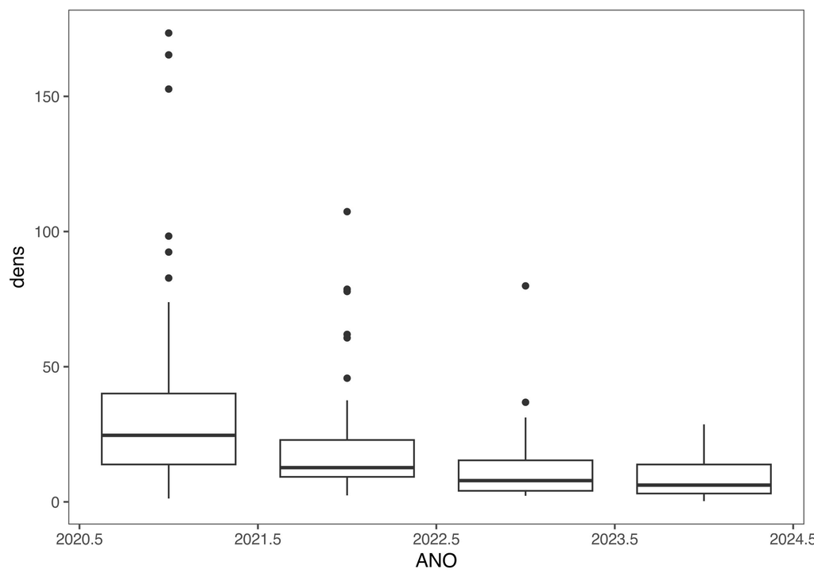

```r
plotdens2124 <- ggplot(denspobtot2 %>%
                         filter(Categoria== "g") %>%
                         group_by(ANO, Sampling.point),
                       aes(ANO, dens, group=ANO))+
  geom_boxplot()+
  theme_few()
plotdens2124
```

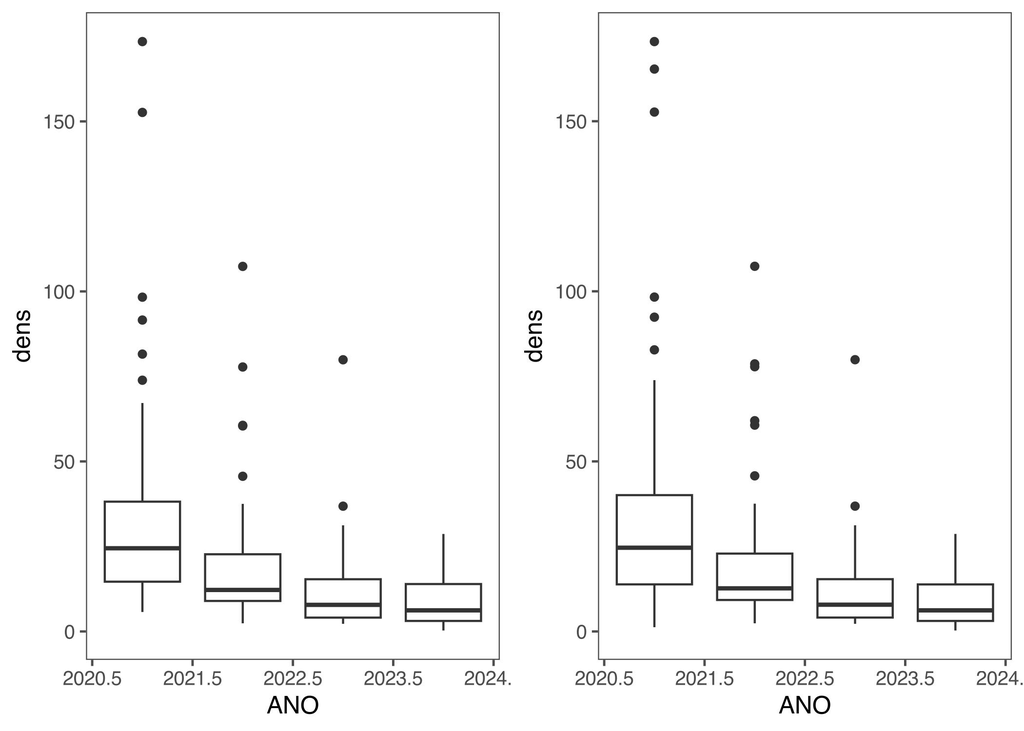

```r
plotdens2124p <- ggplot(denspobtot2 %>%
                         filter(Categoria== "p") %>%
                         group_by(ANO, Sampling.point),
                       aes(ANO, dens, group=ANO))+
  geom_boxplot()+
  theme_few()
ggarrange(plotdens2124p, plotdens2124, ncol=2)
```

Aqui trataré de replicar los rresultados de los Informes de MD en los codes `Pondera1.R` y `Pondera2.R` alojados en este folder. Este hace un cruce con los datos de tallas.

## Base Tallas

```r
size2021 <- read_excel(here("Data",
                            "Posterior 2020",
                            "Data_size_Coquina_2021.xlsx"),
                       sheet = "Coquina_donax") %>%
  select(-c(1, 10, 11))
size2022 <- read_excel(here("Data",
                            "Posterior 2020",
                            "Data_size_Coquina_2022.xlsx"),
                       sheet = "Coquina_donax") %>%
  select(-c(1, 2))
size2023 <- read_excel(here("Data",
                            "Posterior 2020",
                            "Data_size_Coquina_2023.xlsx"),
                       sheet = "Coquina_Donax") %>%
  select(-c(1, 2))
size2024 <- read_excel(here("Data",
                            "Posterior 2020",
                            "Data_size_Coquina_2024.xlsx"),
                       sheet = "Coquina_Donax") %>%
  select(-c(1, 2))
```

```r
size_21_23 <- rbind(size2021,
                    size2022,
                    size2023,
                    size2024)
```

Separate `Date` column

```r
size_21_23<- size_21_23 %>%
  mutate(
    DIA = day(Date),
    MES = month(Date),
    ANO = year(Date)
  )
unique(size_21_23$rastro)
```

```
## [1] "POBLACIONAL" "COMERCIAL"
```

```r
glimpse(size_21_23)
```

```
## Rows: 50,390
## Columns: 12
## $ Date                   <dttm> 2021-01-12, 2021-01-12, 2021-01-12, 2021-01-12…
## $ Beach                  <chr> "Donana_sur", "Donana_sur", "Donana_sur", "Dona…
## $ Sampling.point         <chr> "2", "2", "2", "2", "2", "2", "2", "2", "2", "2…
## $ rastro                 <chr> "POBLACIONAL", "POBLACIONAL", "POBLACIONAL", "P…
## $ CAT                    <dbl> 2, 2, 2, 2, 2, 2, 2, 2, 2, 2, 2, 2, 2, 2, 2, 2,…
## $ Categoria              <chr> "g", "g", "g", "g", "g", "g", "g", "g", "g", "g…
## $ size                   <dbl> 22.39, 23.72, 17.88, 23.98, 22.69, 25.96, 24.46…
## $ sizeE                  <dbl> 22, 23, 17, 23, 22, 25, 24, 24, 22, 22, 24, 22,…
## $ ID_codificado_muestreo <chr> "FEMP_04_2101", "FEMP_04_2101", "FEMP_04_2101",…
## $ DIA                    <int> 12, 12, 12, 12, 12, 12, 12, 12, 12, 12, 12, 12,…
## $ MES                    <dbl> 1, 1, 1, 1, 1, 1, 1, 1, 1, 1, 1, 1, 1, 1, 1, 1,…
## $ ANO                    <dbl> 2021, 2021, 2021, 2021, 2021, 2021, 2021, 2021,…
```

```r
table(size_21_23$ANO, size_21_23$MES)
```

```
##
##           1    2    3    4    5    6    7    8    9   10   11   12
##   2021 3103 1600  897 2399  784 1384 2846  819 1384 2389 1552 2814
##   2022 1374 1156 2560 1673 1013 1857 2577  868    0  996 2619  733
##   2023  915 1040  866  857  732 1068  618  655  639  384  490  772
##   2024  615  374  968    0    0    0    0    0    0    0    0    0
```

```r
size_21_23
```

```
## # A tibble: 50,390 × 12
##    Date                Beach   Sampling.point rastro   CAT Categoria  size sizeE
##    <dttm>              <chr>   <chr>          <chr>  <dbl> <chr>     <dbl> <dbl>
##  1 2021-01-12 00:00:00 Donana… 2              POBLA…     2 g          22.4    22
##  2 2021-01-12 00:00:00 Donana… 2              POBLA…     2 g          23.7    23
##  3 2021-01-12 00:00:00 Donana… 2              POBLA…     2 g          17.9    17
##  4 2021-01-12 00:00:00 Donana… 2              POBLA…     2 g          24.0    23
##  5 2021-01-12 00:00:00 Donana… 2              POBLA…     2 g          22.7    22
##  6 2021-01-12 00:00:00 Donana… 2              POBLA…     2 g          26.0    25
##  7 2021-01-12 00:00:00 Donana… 2              POBLA…     2 g          24.5    24
##  8 2021-01-12 00:00:00 Donana… 2              POBLA…     2 g          24.0    24
##  9 2021-01-12 00:00:00 Donana… 2              POBLA…     2 g          22.4    22
## 10 2021-01-12 00:00:00 Donana… 2              POBLA…     2 g          22.5    22
## # ℹ 50,380 more rows
## # ℹ 4 more variables: ID_codificado_muestreo <chr>, DIA <int>, MES <dbl>,
## #   ANO <dbl>
```

Primero calculo en n de ind medidos y luego junto con base que tiene medida del area `track_m`, que es una variable para estimar `D15` q es en función del área, de acuerdo a lo comentado por MD.

```r
D15n <- size_21_23 %>%
  group_by(ANO,
           MES,
           Sampling.point,
           ID_codificado_muestreo,
           Beach,
           Categoria,
           ) %>%
  summarize(num_individuos = n(), .groups = "drop")

D15n$Sampling.point <- as.double(D15n$Sampling.point)

D15n1 <- left_join(denspobtot2, D15n,
             by = "ID_codificado_muestreo")
```

```r
D15n2 <- D15n1 %>%
  filter(Categoria.x=="p") %>%
  group_by(ANO.x, MES.x, Sampling.point.x, Categoria.x) %>%
  ungroup() %>%
  mutate(num_individuos_m2 = num_individuos / (m_track*0.045)) %>%
  arrange(ANO.x, MES.x) %>%
  filter(ANO.x==2024,
         MES.x==1) %>%
  group_by(Sampling.point.x) %>%
  summarize(across(num_individuos_m2, mean))
```

Obtengo el valor para el informe

```r
D15n2
```

```
## # A tibble: 3 × 2
##   Sampling.point.x num_individuos_m2
##              <dbl>             <dbl>
## 1                2              20.8
## 2                4              20.0
## 3                6              19.5
```

Ahora una grafica para todos los años meses y puntos

```r
D15n3 <- D15n1 %>%
  filter(Categoria.x=="p") %>%
  group_by(ANO.x, MES.x, Sampling.point.x, Categoria.x) %>%
  ungroup() %>%
  mutate(num_individuos_m2 = num_individuos / (m_track*0.045)) %>%
  arrange(ANO.x, MES.x) %>%
  group_by(Sampling.point.x, ANO.x, MES.x) %>%
  summarize(across(num_individuos_m2, mean))
```

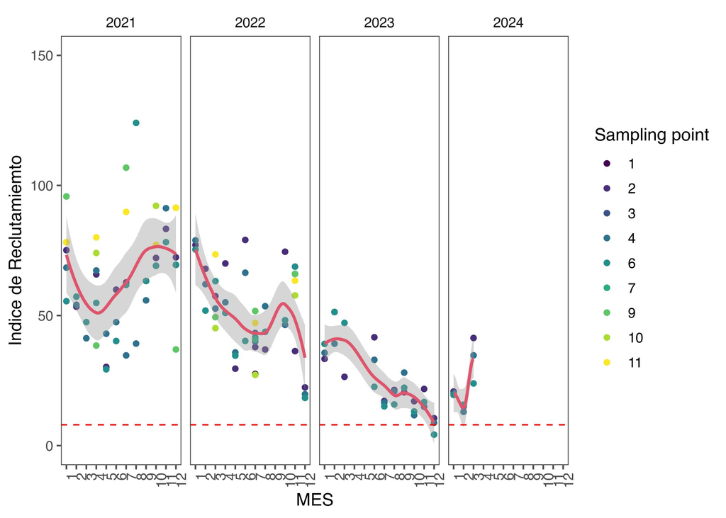

```r
plotD15 <- ggplot(D15n3 %>%
                    drop_na(),
                  aes(MES.x,num_individuos_m2,
                      color=as.factor(Sampling.point.x)))+
  geom_point()+
  geom_smooth(col=2)+
  facet_wrap(.~ANO.x, ncol=4)+
  scale_color_viridis_d(name="Sampling point")+
  scale_x_continuous(breaks = seq(from = 1,
                                  to = 12,
                                  by = 1,
                                  size=2))+
  theme_few()+
  geom_hline(yintercept = 8,
             col="red",
             linetype=2)+
  theme(axis.text.x = element_text(angle = 90,
                                   hjust = 1))+
  ylim(0,150)+
  labs(y="Indice de Reclutamiemto",
       x="MES")
plotD15
```

Esto debemos tratarlo como grupo dado que de acuerdo a la replica de cálculos los valores son mayores que los registrados en los ITAs de los años 2021 y 2023 (Delgado & Silva, 2021, 2023).